# Google Data Analytic Capstone Project

Tran Hoang Phuoc

2023-05-28

# Table of Contens

1. Introduction
2. Business Task
3. Data
4. Processing and Cleaning
5. Analysis and Viz
6. Conclusion and Recommendations

# Introduction

The project is a part of Google Data Analytics Certification course capstone. The scenario involves analysis of the trip data of Cyclistic bike share company.

The company has two models for availing service: individual passes which are called “casual” riders and annual subscriptions called “member” riders. The company operates in Chicago with around 6000 bicycles at 700 stations.

Maximizing the number of annual members will be key to future growth as it ensures financial sustainability and customer retention. The insights can help devise effective marketing strategies aimed to convert more casual riders into annual members.

# Business Task

How do annual members and casual riders use Cyclistic bikes differently ?

> Objective : To clean, analyze and visualize the data to observe how casual riders use the bike rentals differently from annual member riders.

# Data

- Data source : Public data from Motivate International Inc. (Divvy Bicycle Sharing Service from Chicago) under this [license](https://ride.divvybikes.com/data-license-agreement).
- [Cyclistic’ historical trip data](https://divvy-tripdata.s3.amazonaws.com/index.html) (2013 onwards) available in `.csv` format.
- **My date range**: May 2022 to April 2023 (913 MB)
- The dataset has individual ride records consisting of ride start-end date & time, station information, bike type, rider type (casual/member).

# Processing and Cleaning

## Spreadsheet: Microsoft Excel

I initially wanted to gather and analyze my data in Excel because it was the tool I was most familiar with and I could get a general understanding of the data quicker. I did not combine all of the spreadsheets into one because that would’ve taken more processing power than my computer had.

1. I began turning the `.csv` files into excel spreadsheets and downloading the most recent year of data from May 2022 to April 2023.
2. Added two columns to all of the months:
- 1. ride_length: Calculate the length of each ride by subtracting the column “started_at” from the column “ended_at” and format as HH:MM:SS using Format > Cells > Time.
- 2. day_of_week: calculate the day of the week that each ride started using the “WEEKDAY” command and format as DDD Date type.
3. Came up with metrics to look at such as:
- 1. Total number of rides per hour, per day of the week, per day of the month, per season and for different bike types
- 2. Average ride length between members and casual
4. Created Pivot tables and charts for every month:
- 1. Total Rides per Weekday - calculated the total rides for members and casual and separated it by day of the week; used a cluster column chart

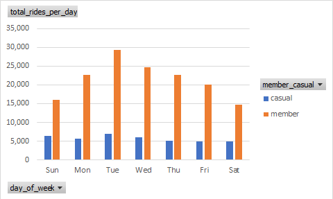

- 2. Total Rides per Hour - calculated the total rides for members and casual separated by the time of the day (24hr); used a line comparison chart

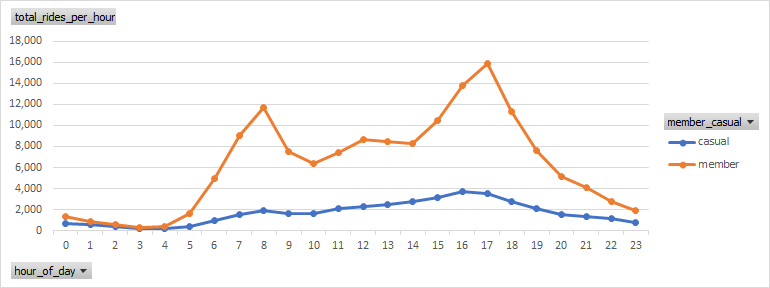

- 3. Total Rides per Day - calculated the total rides for members and casual separated by the day of the month; used a cluster column chart

[figure not shown]

- 4. Total Rides per Bike Type - calculated the total rides for members and casual separated by Bike type; used stacked column chart

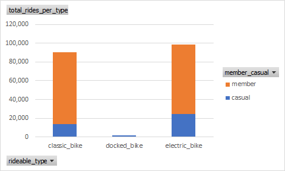

- 5. Average Ride Length - calculated the average ride length for members and casual and separated it by day of the week; used a cluster column chart

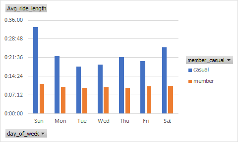

## SQL: Oracle MySQL Workbench

In order to aggregate data from 12 separate monthly CSV files, I decided to use SQL as a data query language to optimize the data cleaning and preparation process for analysis and visualization. Specifically, I chose to use MySQL Workbench because I have invested a significant amount of time familiarizing myself with and using this software.

1. I began importing the 12 data files into MySQL Workbench using the following [query](https://github.com/PhuocTran96/Cyclistic_Analysis/blob/main/docs/import_table_into_mySQL.sql).
2. After completing the data import into MySQL Workbench, I followed these steps to clean and prepare the data:
- 1. Created a temporary table to combine data from the 12 separate files.
- 2. Created another temporary table for calculating ride duration and adding additional columns such as weekday, month, and hour.
- 3. Joined the two temporary tables to display the required information.
- 4. Exported the resulting table, which contained `5,857,272` records (this process took a significant amount of time to complete).

  This is the query I used for these steps: [single query](https://github.com/PhuocTran96/Cyclistic_Analysis/blob/main/docs/query_all_data.sql).
3. The final table had the following structure:

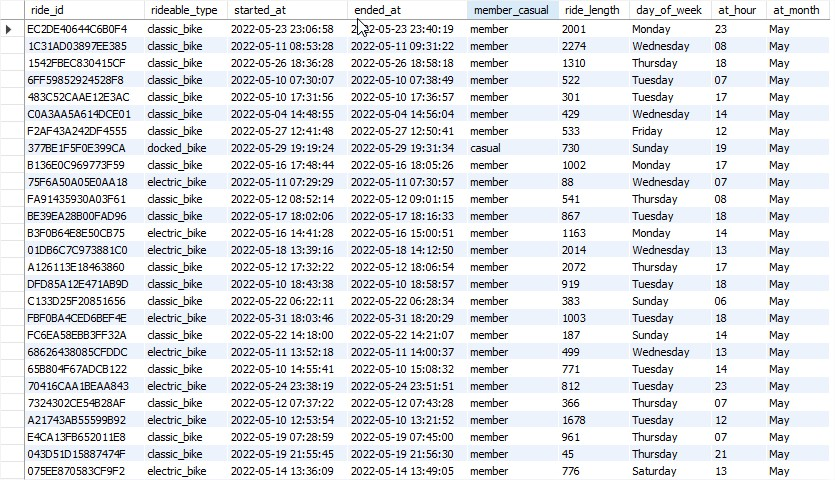

## Programming Language: R

Of course, you can view my script [here](https://github.com/PhuocTran96/Cyclistic_Analysis/blob/main/docs/Cyclistic_project.R).

### Prepare Phase

Load all of the libraries I used: tidyverse, lubridate, hms, data.table

Merged the 12 months of data together using rbind to create a one year view

Created a new data frame called cyclistic_date that would contain all of my new columns

### Process Phase

Created new columns for:

Ride Length - did this by subtracting end_at time from start_at time

Day of the Week - Sun to Sat

Month - Jan to Dec

Day

Year

Hour - as integer

Season - Spring, Summer, Winter or Fall

Time of Day - Night, Morning, Afternoon or Evening

### Cleaning the data

Removing duplicate rows

Remove rows with NA values (blank rows)

Remove where ride_length is < = 0

Remove unnecessary columns: start_station_id, end_station_id, start_lat, start_long, end_lat, end_lng

### Analyze Phase

#### Calculated Total Rides for:

Total number of rides which was just the row count = 4,533,651

Member type - casual riders vs. annual members

Type of Bike - classic vs docked vs electric; separated by member type and total rides for each bike type

Hour - separated by member type and total rides for each hour in a day

Time of Day - separated by member type and total rides for each time of day (morning, afternoon, evening, night)

Day of the Week - separated by member type and total rides for each day of the week

Day of the Month - separated by member type and total rides for each day of the month

Month - separated by member type and total rides for each month

Season - separated by member type and total rides for each season (spring, summer, fall, winter)

#### Calculated Average Ride Length for:

Total average ride length

Member type - casual riders vs. annual members

Type of Bike - separated by member type and average ride length for each bike type

Hour - separated by member type and average ride length for each hour in a day

Time of Day - separated by member type and average ride length for each time of day (morning, afternoon, evening, night)

Day of the Week - separated by member type and average ride length for each day of the week

Day of the Month - separated by member type and average ride length for each day of the month

Month - separated by member type and average ride length for each month

Season - separated by member type and average ride lengths for each season (spring, summer, fall, winter)

Then using all of this data I created my own summary in my case notes and took note of the: total rides for each variable, average ride lengths for each variable, and the difference between members versus casual riders.

### Share Phase

1. Percentage of Member Type:

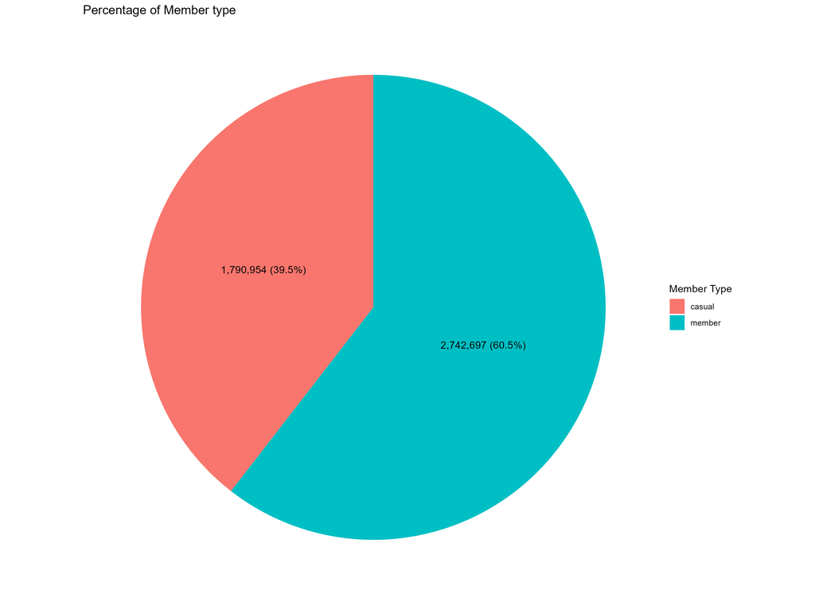

2. Total Ride by Ride Type per Member Type

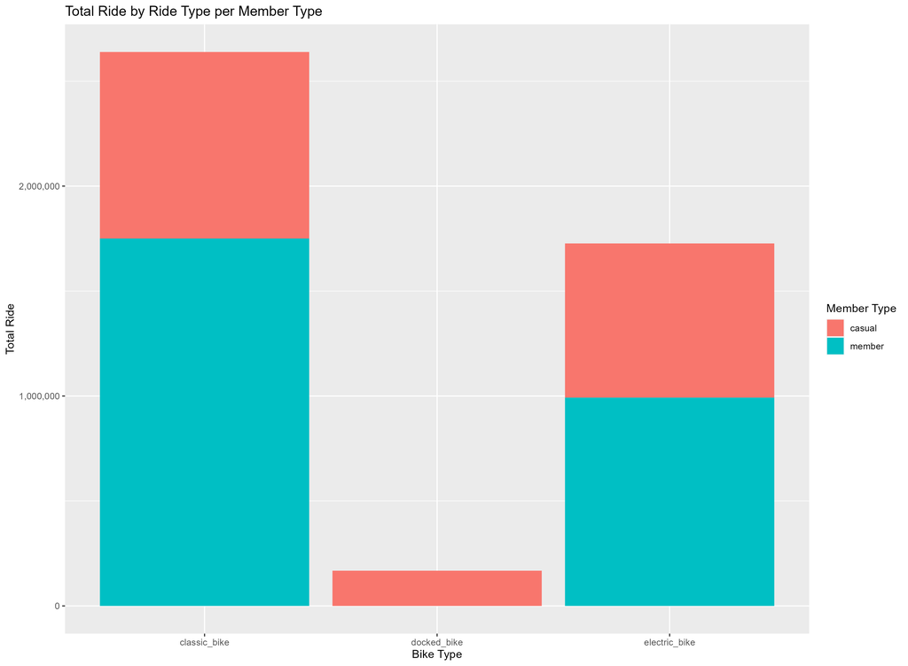

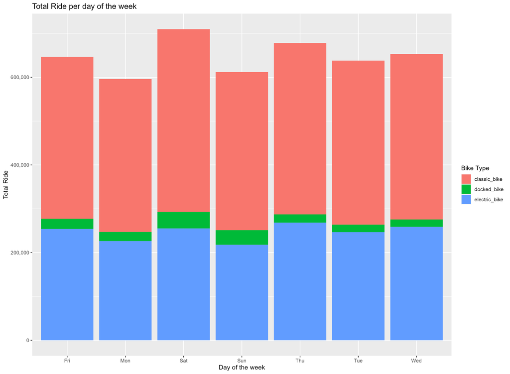

4.Total Rides by Member Type over Days of the Month

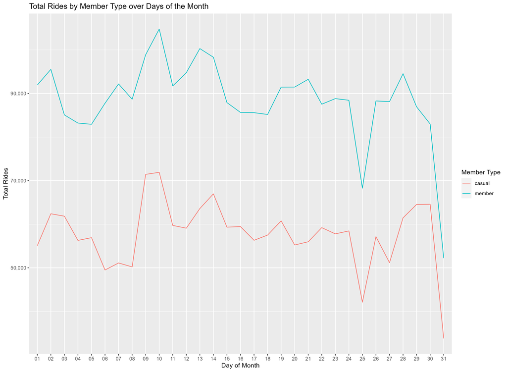

# Analysis and Viz: Miscrosoft Power BI (PBI)

I choose Power BI instead of Tableau for the visualization phase because I have worked with Power BI extensively. I am already familiar with its interface, table relationships and the DAX language (although only at a basic level) for calculations. While Tableau is a good visualization tool, in my opinion, Power BI will continue to gain popularity as the Microsoft Ecosystem expands significantly. Now let’s proceed to the analysis and share phase:

1. Overview of the dashboard: The dashboard in the PBI looks like this

[figure not shown]

2. Total Ride by Member Type:
- Annual members account for a significant portion of the total number of rides (approximately 60%). The company should continue to focus on this major user type to maximize future profits.
- Casual riders represent over one-third (39.5%) of the total rides. If they participate in the Annual Member or another Temporary Member program, it can generate good profits for the company.

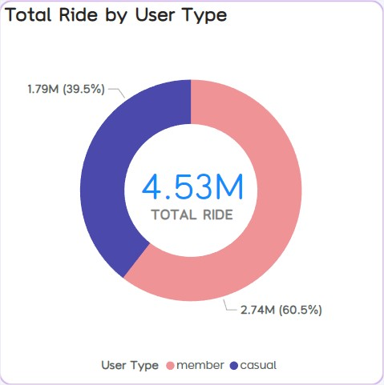

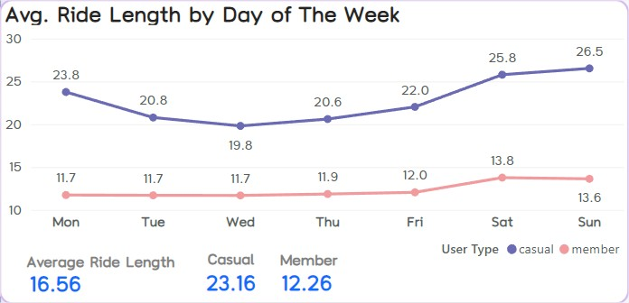

4. Total Ride per Bike Type:
- It is important to note that the count of classic bike rides is much higher for members compared to casual users. This indicates that classic bikes are preferred by members over casual users.
- Electric bikes are also popular among users, with a substantial number of rides recorded for both casual and member users. However, it is worth noting that the count of electric bike rides is higher for members compared to casual users.
- Among the rideable types, docked bikes are the least commonly used.

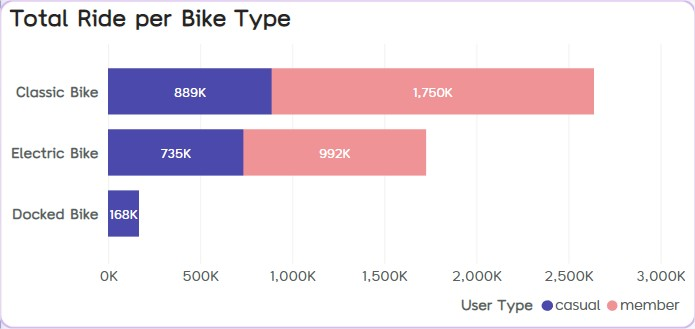

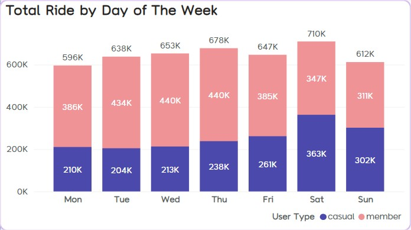

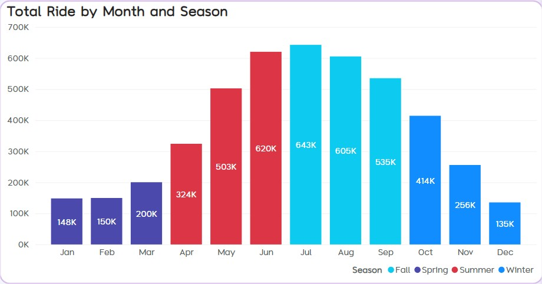

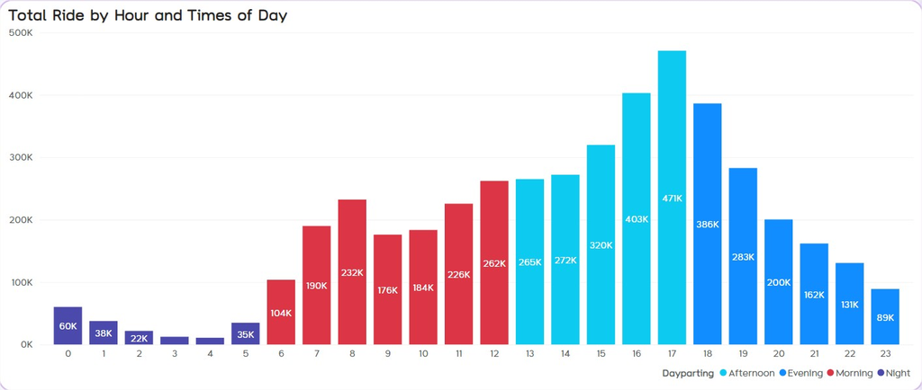

# Conclusion and Recommendations

1. Enhance the bike rental service for casual users: The company can increase advertising efforts and offer promotional campaigns to attract new customers, such as discounted rates for the first hour or day, providing special packages for tourists or event participants.
2. Implement an attractive membership program for member users: The company can create membership packages with special benefits, such as discounted rental rates, extended usage time, or additional services like bike insurance. Additionally, the company should develop loyalty programs to incentive members to use the service during off-peak hours.
3. Invest in infrastructure and services at docking stations: Based on the usage patterns throughout the day, the company can ensure an adequate supply of bikes to meet the highest demand. Additionally, improving the infrastructure at docking stations, such as increasing the number of bike racks or providing supplementary amenities like information boards and maps, can enhance the user experience.
4. Analyze and optimize bike allocation: Utilizing data analysis techniques, the company can gain deeper insights into bike usage patterns and optimize bike allocation. This ensures that bikes are allocated purposefully and efficiently, meeting the users’ needs effectively.